# CodeBook del proyecto - Participación Ciudadana ENAHO

Autogenerated data summary from dataMaid

2026-07-12 19:21:20.587546

# Data report overview

The dataset examined has the following dimensions:

| Feature | Result |
| --- | --- |
| Number of observations | 60080 |
| Number of variables | 19 |

### Checks performed

The following variable checks were performed, depending on the data type of each variable:

|  | character | factor | labelled | haven labelled | numeric | integer | logical | Date |
| --- | --- | --- | --- | --- | --- | --- | --- | --- |
| Identify miscoded missing values | × | × | × | × | × | × |  | × |
| Identify prefixed and suffixed whitespace | × | × | × | × |  |  |  |  |
| Identify levels with < 6 obs. | × | × | × | × |  |  |  |  |
| Identify case issues | × | × | × | × |  |  |  |  |
| Identify misclassified numeric or integer variables | × | × | × | × |  |  |  |  |
| Identify outliers |  |  |  |  | × | × |  | × |

Please note that all numerical values in the following have been rounded to 2 decimals.

# Summary table

|  | Variable class | # unique values | Missing observations | Any problems? |
| --- | --- | --- | --- | --- |
| agua_procedencia_lbl | factor | 8 | 0.00 % |  |
| desague_tipo_lbl | factor | 8 | 0.00 % |  |
| tipo_alumbrado_lbl | factor | 6 | 0.00 % |  |
| edu_nivel_max_lbl | factor | 13 | 0.00 % |  |
| indice_participacion | numeric | 7 | 0.00 % |  |
| participacion_ciudadana | factor | 2 | 0.00 % |  |
| serv_agua_digna_lbl | factor | 2 | 0.00 % |  |
| serv_desague_digno_lbl | factor | 2 | 0.00 % |  |
| serv_energia_digna_lbl | factor | 2 | 0.00 % |  |
| todos_servicios_dignos_lbl | factor | 2 | 0.00 % |  |
| serv_salud_seguro_lbl | factor | 2 | 0.00 % |  |
| seguro_contributivo_lbl | factor | 2 | 0.00 % |  |
| edu_secundaria_completa_lbl | factor | 2 | 0.00 % |  |
| edu_superior_completa_lbl | factor | 2 | 0.00 % |  |
| indice_servicios_dignos | numeric | 6 | 0.00 % |  |
| indice_servicios_dignos_lbl | factor | 3 | 0.00 % |  |
| conglome | integer | 5330 | 0.00 % |  |
| estrato | integer | 8 | 0.00 % |  |
| factor_07 | numeric | 973 | 0.00 % | × |

# Variable list

## agua_procedencia_lbl

*Procedencia del agua en el hogar (Módulo 100: Vivienda y Servicios Básicos)*

| Feature | Result |
| --- | --- |
| Variable type | factor |
| Number of missing obs. | 0 (0 %) |
| Number of unique values | 8 |
| Mode | “Red pública, dentro de la vivienda” |
| Reference category | Camión-cisterna u otro similar |

[figure not shown]

## desague_tipo_lbl

*Tipo de conexión de desagüe del hogar (Módulo 100: Vivienda y Servicios Básicos)*

| Feature | Result |
| --- | --- |
| Variable type | factor |
| Number of missing obs. | 0 (0 %) |
| Number of unique values | 8 |
| Mode | “Red pública de desagüe dentro de la vivienda” |
| Reference category | Campo abierto o al aire libre |

[figure not shown]

## tipo_alumbrado_lbl

*Tipo de alumbrado del hogar, derivado de electricidad/lámpara/vela/generador (Módulo 100: Vivienda y Servicios Básicos)*

| Feature | Result |
| --- | --- |
| Variable type | factor |
| Number of missing obs. | 0 (0 %) |
| Number of unique values | 6 |
| Mode | “Electricidad” |
| Reference category | Electricidad |

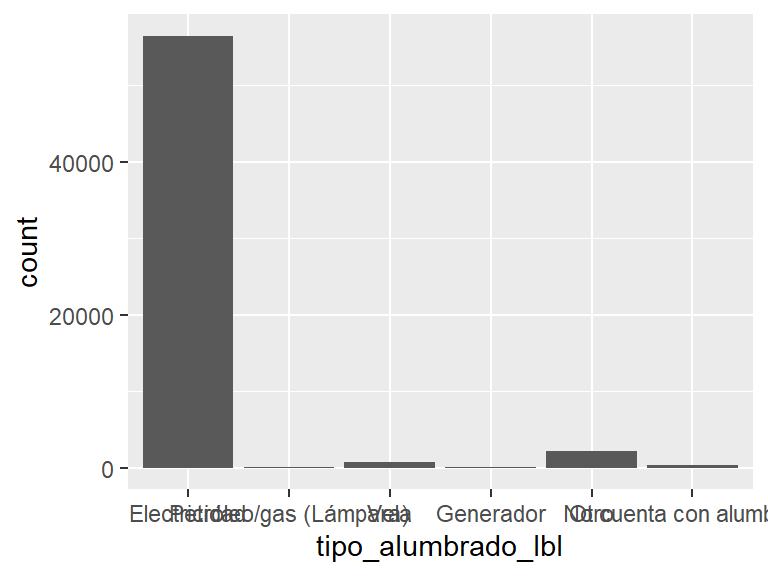

## edu_nivel_max_lbl

*Nivel educativo máximo alcanzado por el encuestado (Módulo 300: Educación)*

| Feature | Result |
| --- | --- |
| Variable type | factor |
| Number of missing obs. | 0 (0 %) |
| Number of unique values | 13 |
| Mode | “Secundaria completa” |
| Reference category | Básica especial |

[figure not shown]

## indice_participacion

*Índice aditivo de participación ciudadana (N° de organizaciones, Módulo 800: Participación, p801_1 a p801_20)*

| Feature | Result |
| --- | --- |
| Variable type | numeric |
| Number of missing obs. | 0 (0 %) |
| Number of unique values | 7 |
| Median | 0 |
| 1st and 3rd quartiles | 0; 1 |
| Min. and max. | 0; 6 |

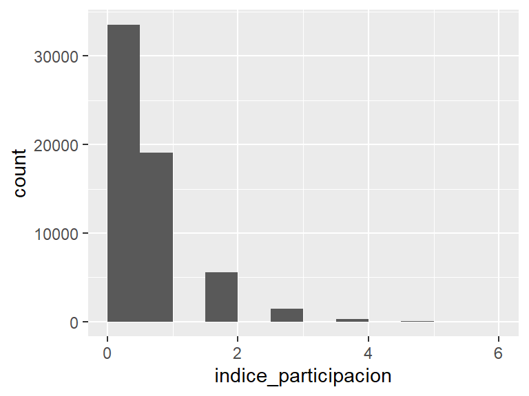

## participacion_ciudadana

*Participa en al menos una organización (Sí/No)*

| Feature | Result |
| --- | --- |
| Variable type | factor |
| Number of missing obs. | 0 (0 %) |
| Number of unique values | 2 |
| Mode | “No” |
| Reference category | No |

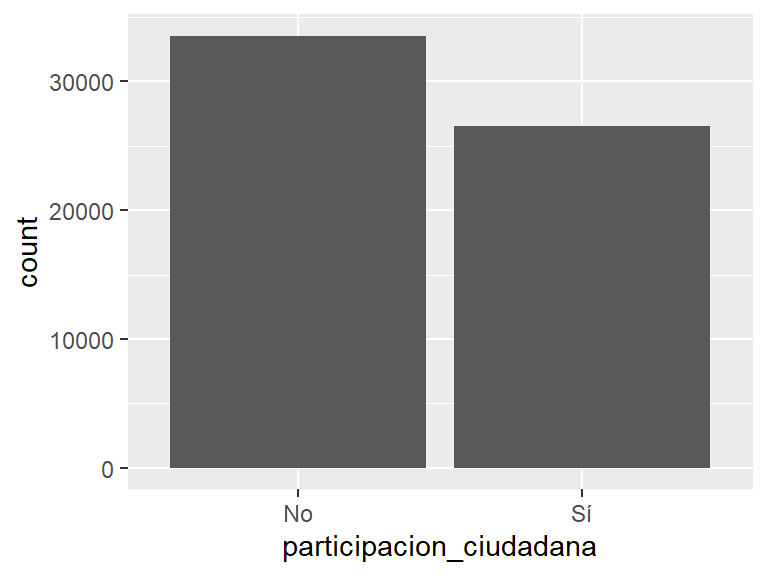

## serv_agua_digna_lbl

*Acceso a agua digna (Sí/No), a partir de agua_procedencia + agua_potable + agua_acceso (Módulo 100)*

| Feature | Result |
| --- | --- |
| Variable type | factor |
| Number of missing obs. | 0 (0 %) |
| Number of unique values | 2 |
| Mode | “Sí” |
| Reference category | No |

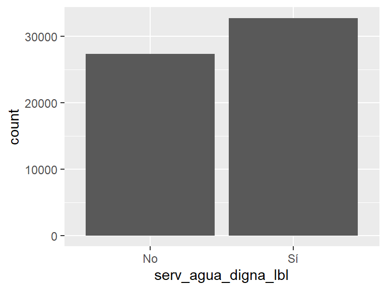

## serv_desague_digno_lbl

*Acceso a desagüe digno (Sí/No), a partir de desague_tipo (Módulo 100)*

| Feature | Result |
| --- | --- |
| Variable type | factor |
| Number of missing obs. | 0 (0 %) |
| Number of unique values | 2 |
| Mode | “Sí” |
| Reference category | No |

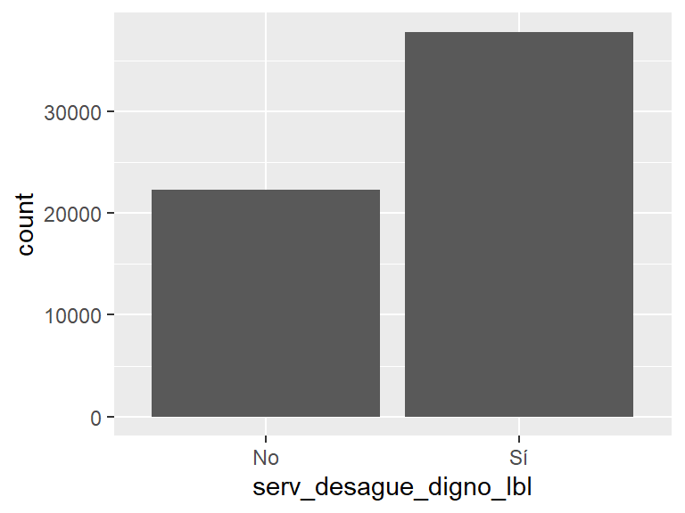

## serv_energia_digna_lbl

*Acceso a energía eléctrica digna (Sí/No), a partir de tipo_alumbrado (Módulo 100)*

| Feature | Result |
| --- | --- |
| Variable type | factor |
| Number of missing obs. | 0 (0 %) |
| Number of unique values | 2 |
| Mode | “Sí” |
| Reference category | No |

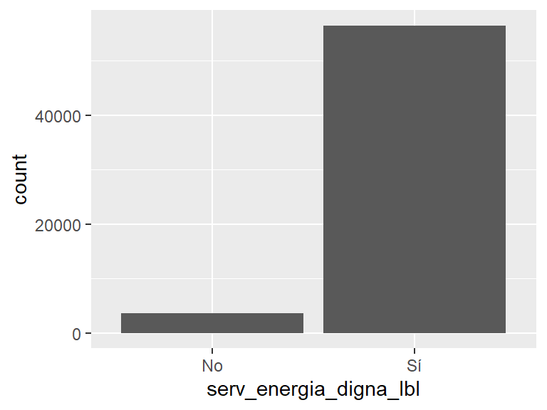

## todos_servicios_dignos_lbl

*Acceso simultáneo a agua, desagüe y energía dignos (Sí/No)*

| Feature | Result |
| --- | --- |
| Variable type | factor |
| Number of missing obs. | 0 (0 %) |
| Number of unique values | 2 |
| Mode | “No” |
| Reference category | No |

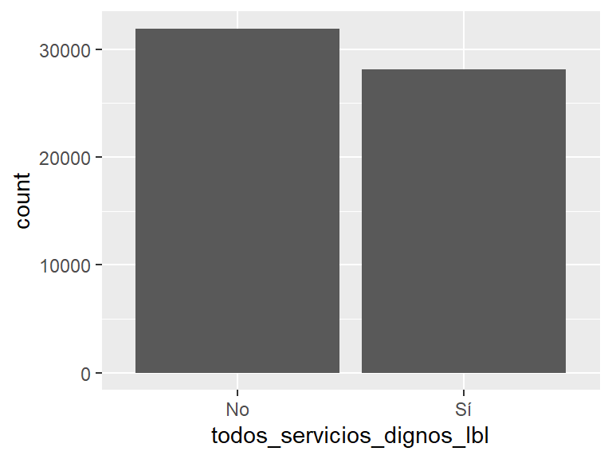

## serv_salud_seguro_lbl

*Cuenta con algún seguro de salud (Sí/No), a partir de seguro_essalud/sis/privado/entidad/ffa_pnp/universitario/escolar (Módulo 400: Salud)*

| Feature | Result |
| --- | --- |
| Variable type | factor |
| Number of missing obs. | 0 (0 %) |
| Number of unique values | 2 |
| Mode | “Sí” |
| Reference category | No |

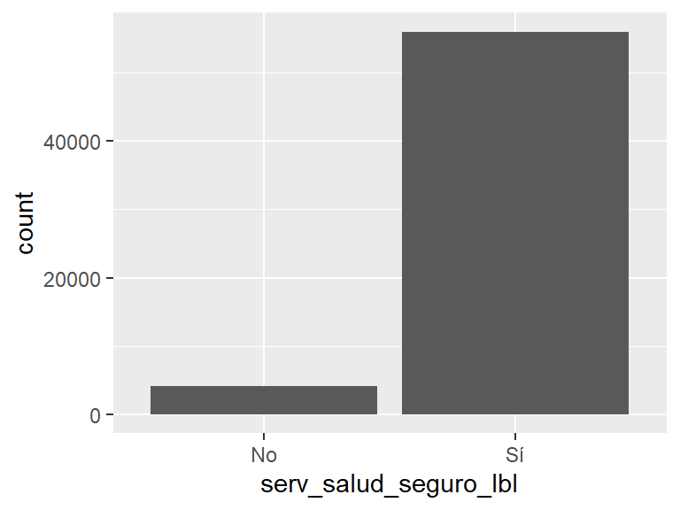

## seguro_contributivo_lbl

*Cuenta con seguro contributivo: Essalud, privado o de entidad (Sí/No) (Módulo 400: Salud)*

| Feature | Result |
| --- | --- |
| Variable type | factor |
| Number of missing obs. | 0 (0 %) |
| Number of unique values | 2 |
| Mode | “No” |
| Reference category | No |

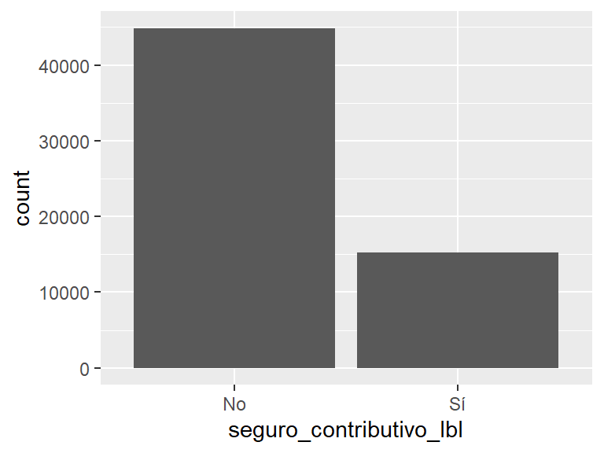

## edu_secundaria_completa_lbl

*Nivel educativo máximo: secundaria completa o superior (Sí/No), a partir de edu_nivel_max (Módulo 300)*

| Feature | Result |
| --- | --- |
| Variable type | factor |
| Number of missing obs. | 0 (0 %) |
| Number of unique values | 2 |
| Mode | “No” |
| Reference category | No |

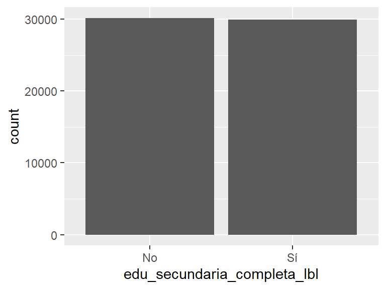

## edu_superior_completa_lbl

*Nivel educativo máximo: superior completa (Sí/No), a partir de edu_nivel_max (Módulo 300)*

| Feature | Result |
| --- | --- |
| Variable type | factor |
| Number of missing obs. | 0 (0 %) |
| Number of unique values | 2 |
| Mode | “No” |
| Reference category | No |

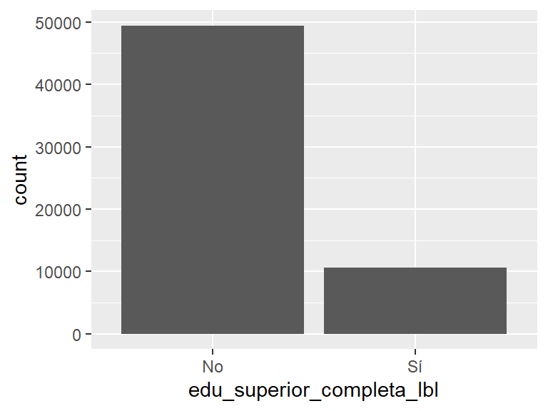

## indice_servicios_dignos

*Índice aditivo de acceso a servicios dignos (0-5)*

| Feature | Result |
| --- | --- |
| Variable type | numeric |
| Number of missing obs. | 0 (0 %) |
| Number of unique values | 6 |
| Median | 4 |
| 1st and 3rd quartiles | 3; 5 |
| Min. and max. | 0; 5 |

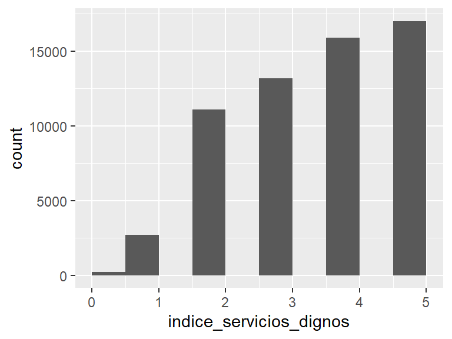

## indice_servicios_dignos_lbl

*Nivel de acceso a servicios dignos (Bajo/Medio/Alto)*

| Feature | Result |
| --- | --- |
| Variable type | factor |
| Number of missing obs. | 0 (0 %) |
| Number of unique values | 3 |
| Mode | “Acceso Medio (3-4 recursos)” |
| Reference category | Acceso Bajo (0-2 recursos) |

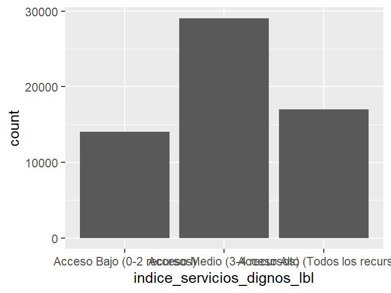

## conglome

*Conglomerado (identificador de conglomerado muestral ENAHO)*

| Feature | Result |
| --- | --- |
| Variable type | integer |
| Number of missing obs. | 0 (0 %) |
| Number of unique values | 5330 |
| Median | 17694 |
| 1st and 3rd quartiles | 16376; 19231 |
| Min. and max. | 15001; 21015 |

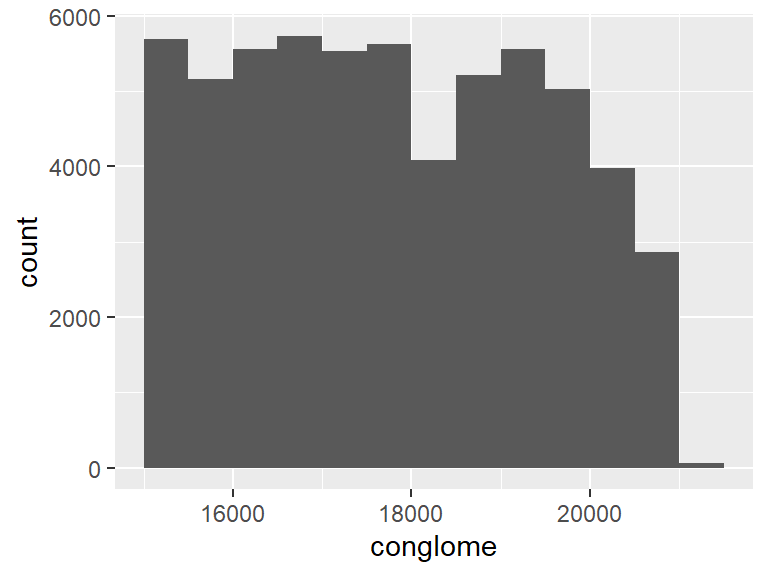

## estrato

*Estrato de la muestra ENAHO*

| Feature | Result |
| --- | --- |
| Variable type | integer |
| Number of missing obs. | 0 (0 %) |
| Number of unique values | 8 |
| Median | 4 |
| 1st and 3rd quartiles | 2; 7 |
| Min. and max. | 1; 8 |

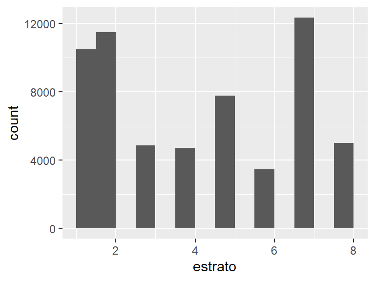

## factor_07

*Factor de expansión poblacional (ponderador ENAHO)*

| Feature | Result |
| --- | --- |
| Variable type | numeric |
| Number of missing obs. | 0 (0 %) |
| Number of unique values | 973 |
| Median | 238.69 |
| 1st and 3rd quartiles | 124.99; 372.38 |
| Min. and max. | 1.66; 1845.74 |

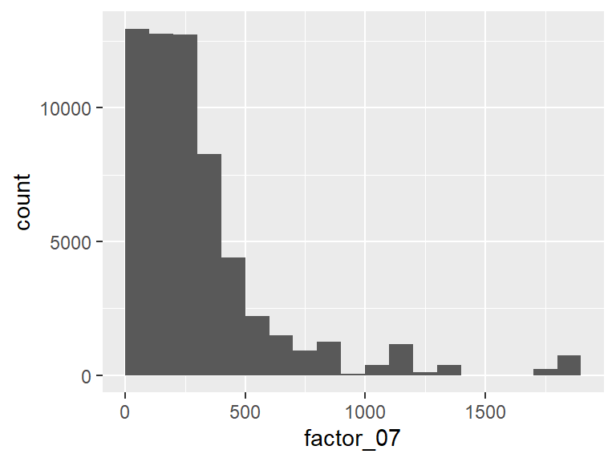

- Note that the following possible outlier values were detected: "1049.76", "1076.56", "1076.56", "1079.35", "1084.17", …, "1748.51", "1821.81", "1843.93", "1843.93", "1845.74" (17 values omitted).

Report generation information:

- Created by: Kyale33 (username: `Kyara`).
- Report creation time: dom. jul. 12 2026 19:21:30
- Report was run from directory: `C:/Users/Kyara/Desktop/Práctica Calificada 3`
- dataMaid v1.4.2 [Pkg: 2025-04-13 from standard (@1.4.2)]
- R version 4.4.1 (2024-06-14 ucrt).
- Platform: x86_64-w64-mingw32/x64(America/Lima).
- Function call: `makeDataReport(data = enaho_codebook, output = "html", file = here("outputs", "CodeBook_dataMaid.Rmd"), replace = TRUE, reportTitle = "CodeBook del proyecto - Participación Ciudadana ENAHO")`